# The Anatomy of a Plot

Johan Larsson

To reason about visualizations we need to know a little bit about the anatomy of a plot and in this text we’ll talk about some of the fundamental parts of a plot so that you know the lingo that we’ll be using extensively throughout this course.

To get going, we first need a plot to focus on. We’ll use a simple plot of horsepower versus fuel consumption from the `mtcars` dataset.

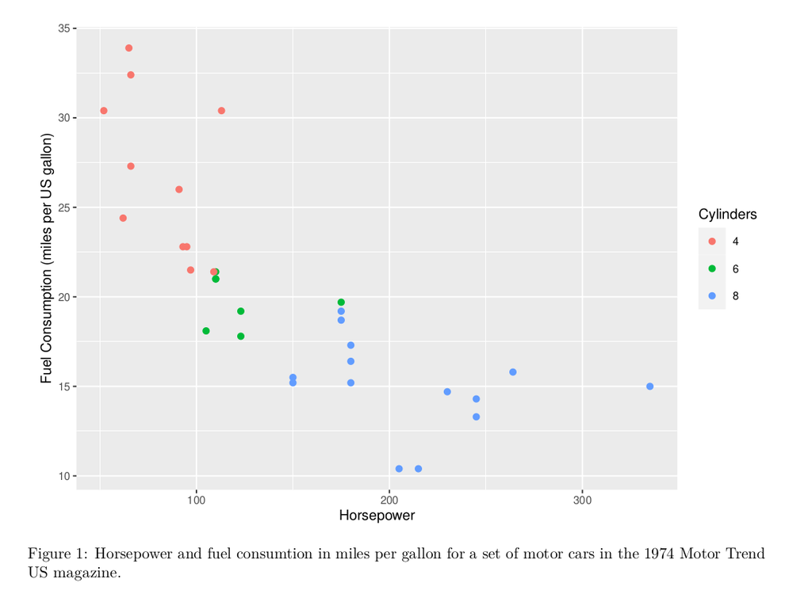

To produce the plot, simply run the following code.

```r
library(tidyverse)

mtcars %>%
  mutate(cyl = as.factor(cyl)) %>%
  ggplot(aes(hp, mpg, color = cyl)) +
  geom_point() +
  labs(x = "Horsepower",
       y = "Fuel Consumption (miles per US gallon)",
       color = "Cylinders")
```

## The Canvas

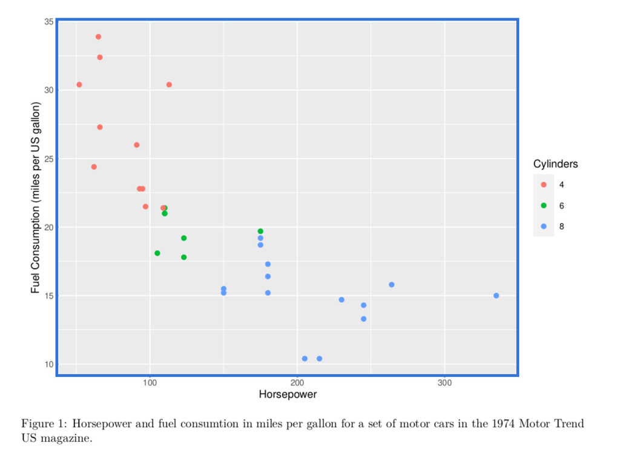

The canvas, also called the plot area, is the area on which the data is drawn. Everything outside of the canvas will be annotations and usually don’t display data directly.

If you use facets in your plot, you might have several canvasses in a visualization. We’ll discuss facets in detail later, but for now it’s sufficient that you think of facets as multiple plots that you line up one after the other.

## Grid

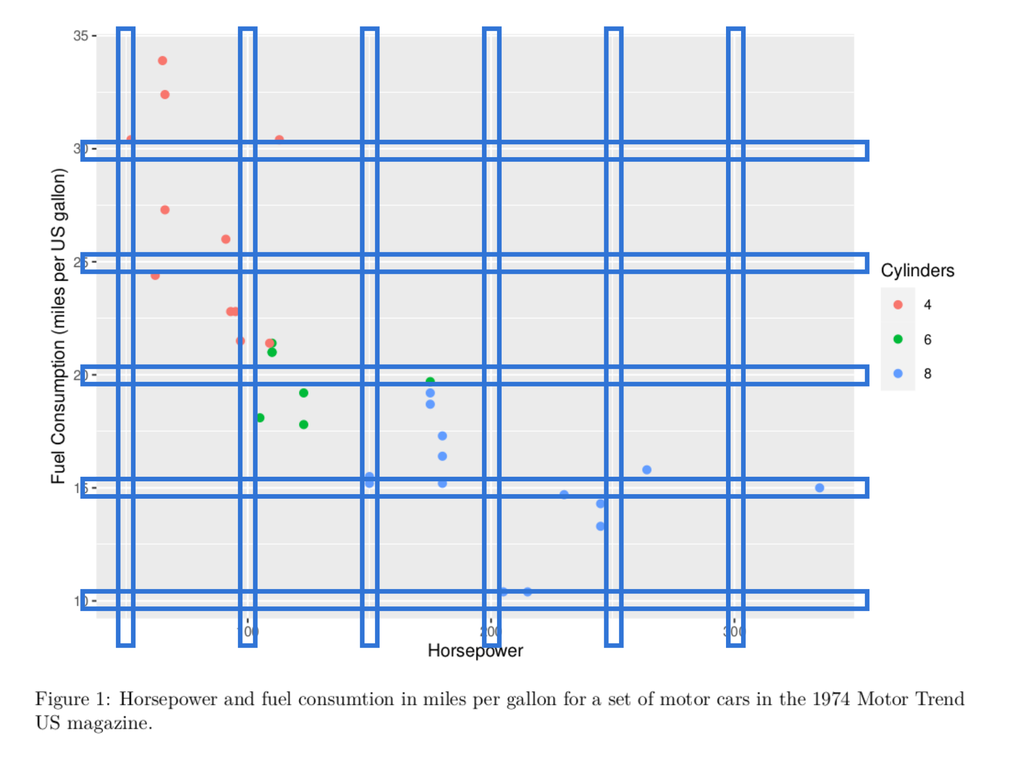

Sometimes, as in the default ggplot2 theme, the canvas is divided into sections by a grid. A grid often makes it easier to compare data points, especially when they are far apart. Grids are particularly useful when there are few observations in a visualization.

Grids often have major and minor gridlines, which is also true for this plot, although the difference is slight.

## Geoms

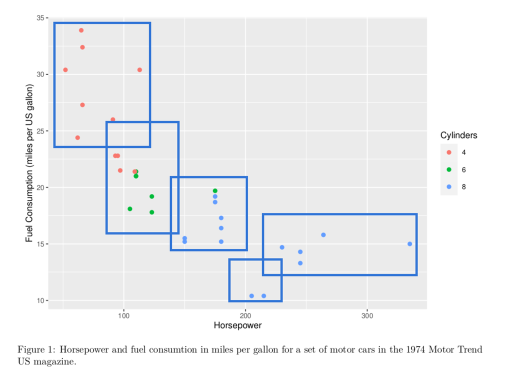

The geoms in the plot are geometrical shapes that are used to draw data. Here we are using points as our geoms.

## Axes

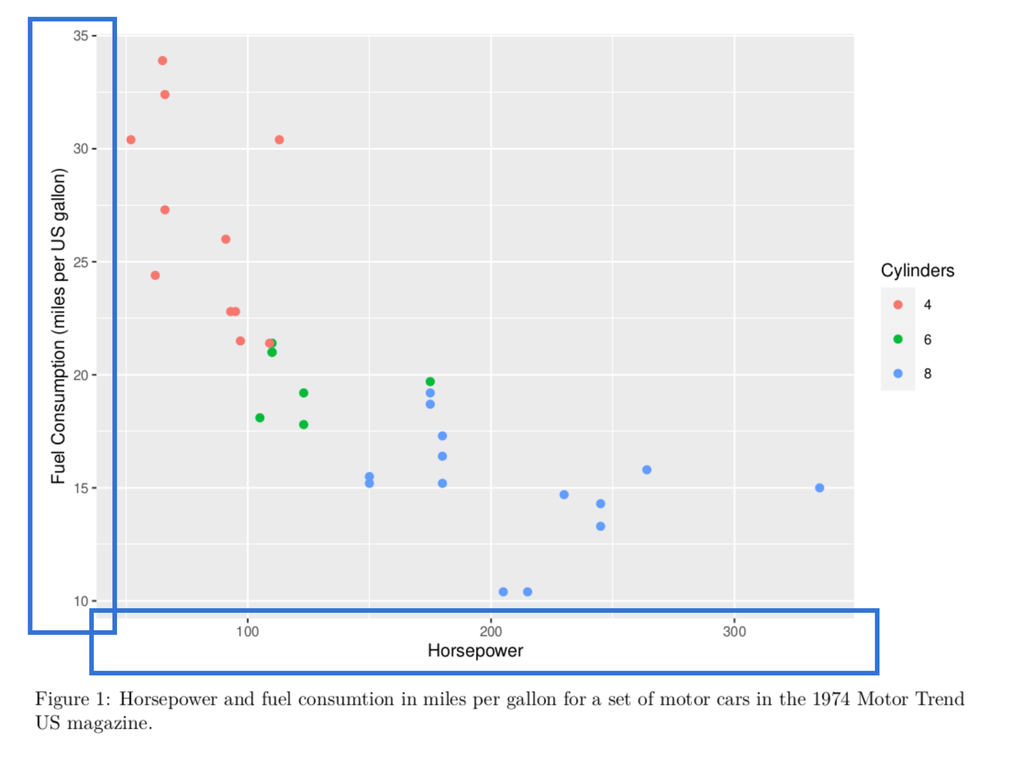

The axes is a guide for the connection between the coordinates of the geoms and the variables they are mapped to. Without the axes, we would only see the pattern of points and not the values these points represent.

On each axis there are numbers or words and they are connected via *ticks* or *tickmarks* to the gridlines.

## Legends

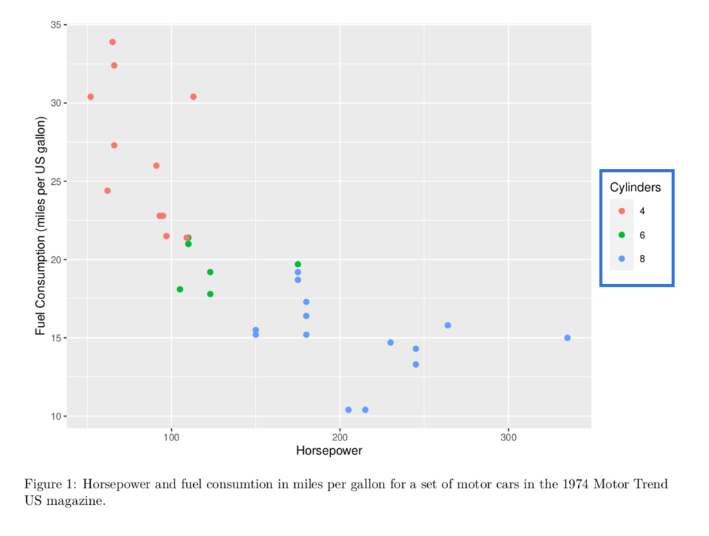

A legend is a guide that helps you read an aesthetic mapped to a variable in the plot. The legend in this plot links a color scale to the number of cylinders.

The legend is sometimes also called a *key*.

## Titles

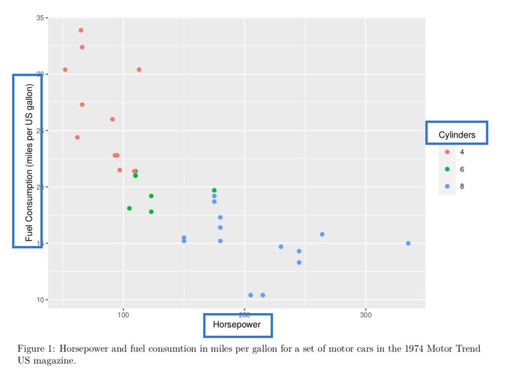

The axes should almost always have titles. Titles should be informative and if it is not otherwise clear from the caption (see below), they should also indicate the unit of measurement if it is not obvious from context. In this plot, for instance, the unit for fuel consumption is given in parenthesis. Sometimes a slash is used instead.

How to format the titles varies depending on the publication. Title or sentence case are the two most common choices, but lower case can be fine too.

**title case**

A Nice Title of Something Important

**sentence case**

A nice title of something important

**lower case**

a nice title of something important

A title should not end with a period unless it is a full sentence.

If it not immediately clear from the categories of the legend, the legend should also have a title. Some people like to use a main title (and even subtitle) for the visualization as well (using `ggtitle()` or `labs(title = "some title")`), but this is usually not necessary and even frowned upon in some formal contexts.

## Caption

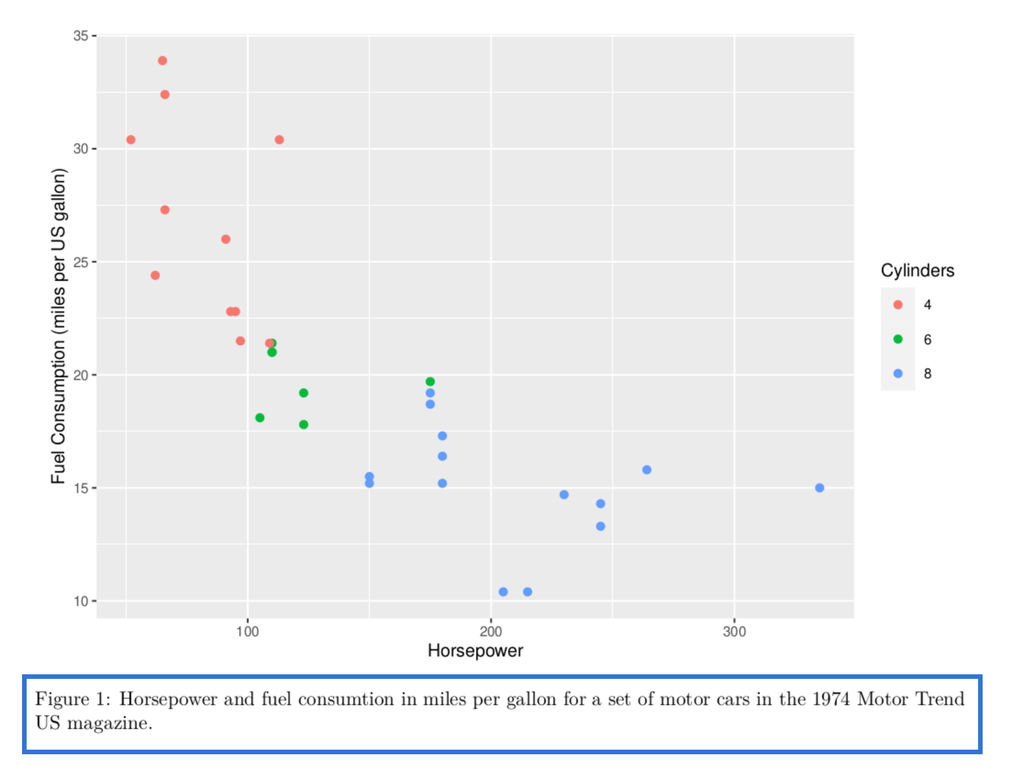

When including a visualization in a report, it should always have a numbered caption. The caption should make the entire visualization self-explanatory. Details should be provided in the main body of the text, but given the caption and the visualization, any reader should be able to interpret the plot.

Note that the captions will be numbered automatically if you use R Markdown; most WYSIWYG editors (such as Microsoft Word) are also able to number figures.